# MLB mock report

```
Report date: 2022-10-11
League name: National League
```

## League standings

Time series evolution of number of wins and win-total ratio:

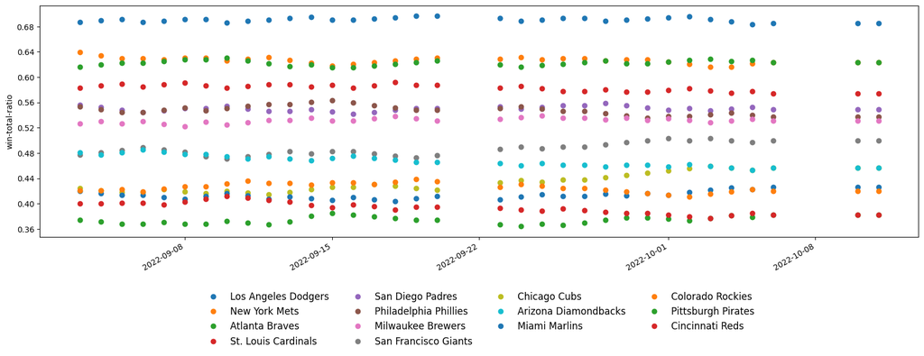

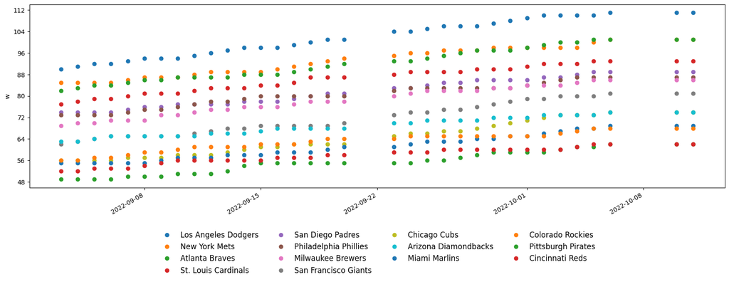

## Batting summary

Time series evolution of home runs and obp:

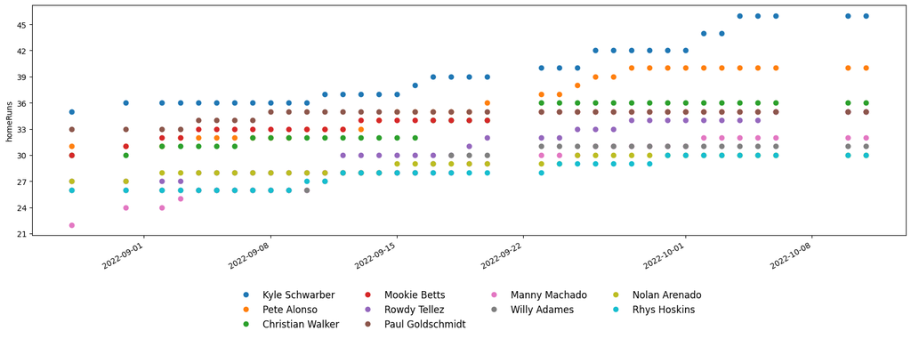

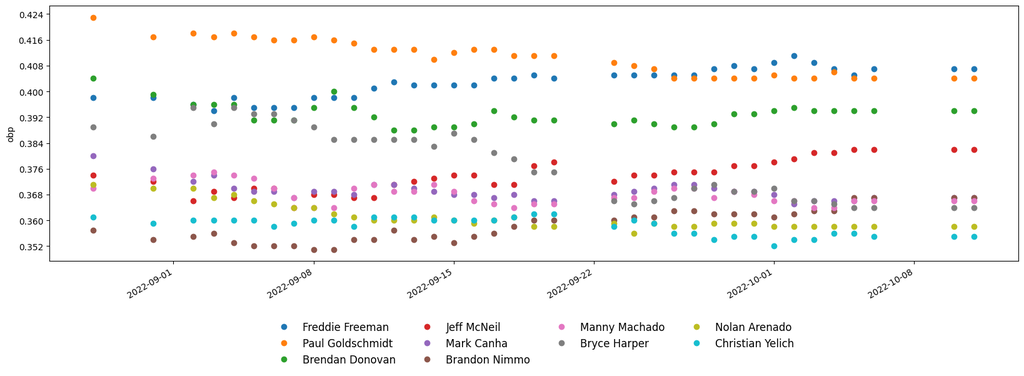

### Runs batted in (RBI)

Who is really 🔥💥 ?

|  | playername | rbiperplateAppearance |
| --- | --- | --- |
| 405395 | Albert Pujols | 0.193730 |
| 624413 | Pete Alonso | 0.191240 |
| 502671 | Paul Goldschmidt | 0.176650 |
| 571448 | Nolan Arenado | 0.166130 |
| 592626 | Joc Pederson | 0.161660 |
| 543068 | C.J. Cron | 0.161390 |
| 642715 | Willy Adames | 0.158830 |
| 592518 | Manny Machado | 0.158390 |
| 592273 | Brandon Drury | 0.153010 |
| 547180 | Bryce Harper | 0.152580 |

And who is not 🧊🐢 ?

|  | playername | rbiperplateAppearance |
| --- | --- | --- |
| 663897 | Luke Williams | 0.024190 |
| 663611 | Nick Madrigal | 0.030700 |
| 605244 | Aramis Garcia | 0.034780 |
| 645444 | Jose Herrera | 0.040320 |
| 640492 | Jose Azocar | 0.046300 |
| 641645 | Luis Guillorme | 0.050750 |
| 514917 | Cesar Hernandez | 0.055110 |
| 676480 | Jose Barrero | 0.057470 |
| 656582 | Connor Joe | 0.059960 |
| 650331 | Lewin Diaz | 0.063220 |

Who to watch? Biggest improvement from last week:

|  | playername | rbiperplateAppearancedifference |
| --- | --- | --- |
| 623520 | David Bote | 0.037110 |
| 668715 | Spencer Steer | 0.014070 |
| 543510 | James McCann | 0.012270 |
| 681584 | David Villar | 0.011910 |
| 656180 | Riley Adams | 0.011880 |
| 664731 | P.J. Higgins | 0.010470 |
| 669743 | Alex Call | 0.008280 |
| 607043 | Brandon Nimmo | 0.007880 |
| 668709 | JJ Bleday | 0.007140 |
| 592192 | Mark Canha | 0.006890 |

### Homeruns (HRs)

Who is really 🔥💥 ?

|  | playername | homeRunsperplateAppearance |
| --- | --- | --- |
| 656941 | Kyle Schwarber | 0.068760 |
| 405395 | Albert Pujols | 0.068380 |
| 642133 | Rowdy Tellez | 0.058430 |
| 624413 | Pete Alonso | 0.058390 |
| 592669 | Hunter Renfroe | 0.055560 |
| 663586 | Austin Riley | 0.054830 |
| 605141 | Mookie Betts | 0.054770 |
| 608841 | Joey Meneses | 0.054170 |
| 572233 | Christian Walker | 0.053970 |
| 502671 | Paul Goldschmidt | 0.053760 |

And who is not 🧊🐢 ?

|  | playername | homeRunsperplateAppearance |
| --- | --- | --- |
| 645444 | Jose Herrera | 0.000000 |
| 663611 | Nick Madrigal | 0.000000 |
| 640492 | Jose Azocar | 0.000000 |
| 514917 | Cesar Hernandez | 0.001620 |
| 602074 | Yonathan Daza | 0.004900 |
| 641645 | Luis Guillorme | 0.005970 |
| 641511 | Jason Delay | 0.005990 |
| 664670 | Alejo Lopez | 0.006410 |
| 578428 | Jose Iglesias | 0.006420 |
| 621028 | Kevin Newman | 0.006470 |

Who to watch? Biggest improvement from last week:

|  | playername | homeRunsperplateAppearancedifference |
| --- | --- | --- |
| 681584 | David Villar | 0.009490 |
| 682998 | Corbin Carroll | 0.007510 |
| 623520 | David Bote | 0.006910 |
| 656180 | Riley Adams | 0.005940 |
| 669743 | Alex Call | 0.005380 |
| 543510 | James McCann | 0.004780 |
| 663743 | Nick Fortes | 0.003310 |
| 607043 | Brandon Nimmo | 0.002720 |
| 596103 | Austin Slater | 0.002610 |
| 660821 | Jesus Sanchez | 0.002080 |

### Strike-outs

Remember, unlike runs batted in and home-runs, strike-outs are bad! You cannot score runs if you do not put the ball in play!

Who is really 🔥💥 ?

|  | playername | strikeOutsperplateAppearance |
| --- | --- | --- |
| 643446 | Jeff McNeil | 0.103565 |
| 545121 | Ildemaro Vargas | 0.107143 |
| 663538 | Nico Hoerner | 0.110251 |
| 660688 | Keibert Ruiz | 0.115473 |
| 571448 | Nolan Arenado | 0.116129 |
| 663611 | Nick Madrigal | 0.118421 |
| 578428 | Jose Iglesias | 0.119914 |
| 500743 | Miguel Rojas | 0.120316 |
| 664670 | Alejo Lopez | 0.134615 |
| 621563 | Joey Wendle | 0.134771 |

And who is not 🧊🐢 ?

|  | playername | strikeOutsperplateAppearance |
| --- | --- | --- |
| 676480 | Jose Barrero | 0.436782 |
| 669374 | Keston Hiura | 0.417293 |
| 608336 | Joey Gallo | 0.388278 |
| 663698 | Joey Bart | 0.384880 |
| 614177 | Franmil Reyes | 0.371429 |
| 669911 | Michael Toglia | 0.366667 |
| 606157 | Aristides Aquino | 0.365942 |
| 595751 | Jorge Alfaro | 0.357664 |
| 605204 | J.D. Davis | 0.354430 |
| 623520 | David Bote | 0.354331 |

Who to watch? Biggest improvement from last week:

|  | playername | strikeOutsperplateAppearancedifference |
| --- | --- | --- |
| 681584 | David Villar | -0.012890 |
| 676480 | Jose Barrero | -0.006330 |
| 623520 | David Bote | -0.006330 |
| 668709 | JJ Bleday | -0.006040 |
| 605244 | Aramis Garcia | -0.005230 |
| 666801 | Rodolfo Castro | -0.005190 |
| 669374 | Keston Hiura | -0.005190 |
| 663743 | Nick Fortes | -0.004810 |
| 613564 | Jason Vosler | -0.004790 |
| 657557 | Paul DeJong | -0.004390 |